# Comparing Models for Prediction of Horsepower from MPG

10/16/2017

## Background

During the Coursera class 'Developing Data Products,' students were introduced to methods for fitting a dataset with a model to generate a prediction. In this course, linear and hockeystick models were fit to horsepower vs. MPG data from the R dataset, mtcars.

Neither the linear or hockeystick models actually make sense for the data, from a mechanistic point-of-view. For example, both models would produce negative values for horsepower at high MPG and both models would allow negative values of MPG. However, an exponential model makes intuitive sense since it would not produce negative value predictions or allow negative values for the input.

## Exponential Model Fit of HP vs. MPG

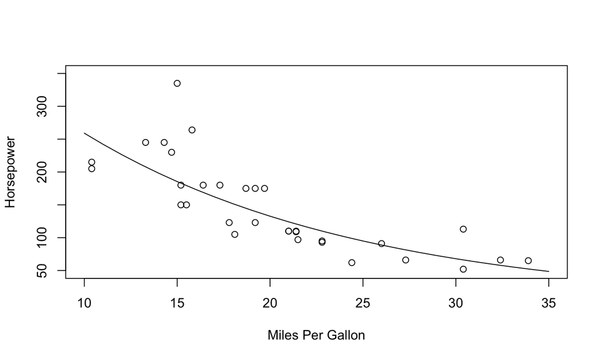

```r
model3 <- lm(log(hp) ~  mpg, data = mtcars)
plot(mtcars$mpg, mtcars$hp, xlab = "Miles Per Gallon",
     ylab = "Horsepower", xlim = c(10, 35), ylim = c(50, 350))
lines(10:35, exp(predict(model3, newdata = data.frame(mpg = 10:35))))
```

## Bootstrapping to calculate error

```r
  model3boot <- reactive({
    mpgInput <- input$sliderMPG
    value_slider <- function(formula, data, indices) {
      d <- data[indices,] # allows boot to select sample
      fit <- lm(formula, data=d)
      return(exp(predict(fit, newdata = data.frame(mpg = mpgInput))))
    }
    results <- boot(data=mtcars, statistic=value_slider,
                    R=500, formula=log(hp) ~  mpg)
    ci <- boot.ci(results, type="bca")
    return(ci$bca[4:5])
  })
```

## Conclusions

To try the app: https://gjboggy.shinyapps.io/DataProductsFinalProject/